# 第十二课笔记—— 时间序列

[figure not shown]

# 平稳性

假定时间序列${𝑌 𝑡:𝑡 = 0,±1,±2,……}$ 的每一个数值都是从一个概率分布中随机得到，如果满足下列条件：

- $均值𝐸 𝑌 𝑡 = 𝜇与时间t无关的常数$；
- $方差𝑉𝑎𝑟 𝑌 𝑡 = 𝛾$与时间t 无关的常数$；
- $协方差𝐶𝑜𝑣 𝑌 𝑡,𝑌 𝑡+𝑘 = 𝛾0,𝑘 只与时期间隔 k 有关，与时间t 无关的常数$。

则称该随机时间序列是平稳的（stationary)

### 验证方法

- 图检验
  - 时序图检验、自相关图检验
  - 操作简单、应用广泛
  - 带有主观性

    从一个模型的图上观察，如果一个模型是呈趋势性（增长或下降）的、或者有周期性的(有规律的），则这不是一个平稳的模型。因为这说明Y的均值、方差和协方差与时间t是有关联的，不是随机的。 平稳模型的自相关系数随着时间t的增长而趋于零。
- 假设检验：构造检验统计量
  - 单位根检验：$如果p-value>0.05，则不能拒绝h_0:存在单位根，说明该模型是不平稳的$。

$单位根：n次单位根是n次幂为1的复数。它们位于复平面的单位圆上，构成正n边形的顶点，其中一个顶点是1。$

$$z^n = 1$$

这方程的复数根 $z$ 为 **n次单位根**。

$$e^\frac{2 Π k_i}{ n } = 1$$

$单位的n次根以乘法构成n阶循环群。$

$单位根（unit root）设n 是正整数，当一个数的n 次乘方等于1 时，称此数为n 次“单位根”。$

$在复数范围内，n 次单位根有n 个。例如，1、－1、i、－i 都是4次单位根。确切的说，单位根指模为1的根，一般的x的n个单位根可以表示为：$

$$x = cos \frac{2 k Π}{ n } + sin \frac{2 k Π}{ n } * i= 1$$

# 白噪声检验

**纯随机过程 == 白噪声**

如果是一个纯随机过程，序列之间没有任何关联。 虽然序列会在一个常数附近波动，但是序列之间没有自相关性。 自相关性检测会发现，白噪声的序列的值在0附近进行随即徘徊。此时就不需要再进行白噪声检验。

[figure not shown]

- LB 统计量

计算所有的序列之间的相关系数，再进行白噪声判断，可以判断出是否是一个平稳的随机序列。

- Q统计量

$ H_0:该序列是一个随机序列（白噪声序列）。 $

$ H_1：该序列不是一个随机序列（白噪声序列）。 $

## 平稳时间序列分析

[figure not shown]

# 自回归模型 AR

AR是一个自回归的方程，通过对前P期的自变量来进行t-p期的值的影响。 均值为0，方差为常数，各项之间不相关。

[figure not shown]

**自相关系数 ACF （Auto-correlation coefficient）**：

自相关系数是两个不同事件彼此之间的相互影响程度；而自相关系数度量的是同一事件在两个不同时期之间的相关程度，形象的讲就是度量自己过去的行为对自己现在的影响。

在时间序列分析分析中，$对于时间序列{Xt，x∈T}，任取t，s∈T，定于γ(t,s)为序列{Xt}的自协方差函数$：

$$γ(t,s)=E(Xt-μt)(Xs-μs)$$

定义$ρ(t,s)为时间序列{Xt}$的自相关系数，简记为ACF：

$$ρ(t,s)= γ(t,s)/sqrt(DXt×DXs)$$

其中，$E表示数学期望，D表示方差。$

**偏自相关系数 PACF**：

**偏相关分析 PCF (Partial correlation coefficient)**

在多要素所构成的系统中，当研究某一个要素对另一个要素的影响或相关程度时，把其他要素的影响视作常数（保持不变），即暂时不考虑其他要素影响，单独研究两个要素之间的相互关系的密切程度，所得数值结果为偏相关系数。

指当两个变量同时与第三个变量相关时，将第三个变量的影响剔除，只分析另外两个变量之间相关程度的过程，判定指标是相关系数的R值。

当分析P1,P2,P3期的影响时，把P2期去除掉，只分析P1与P3期的关系

p值是针对原假设H0：假设两变量无线性相关而言的。一般假设检验的显著性水平为0.05，你只需要拿p值和0.05进行比较：

如果p值小于0.05，就拒绝原假设H0，说明两变量有线性相关的关系，他们无线性相关的可能性小于0.05；

如果大于0.05，则一般认为无线性相关关系，至于相关的程度则要看相关系数R值，R越大，说明越相关。越小，则相关程度越低。

### q阶滑动平均模型

[figure not shown]

通过对残差进行随机摇动向分析

# 自回归滑动平均模型 ARMA(p+q)

== AR+MA

[figure not shown]

# 非平稳时间序列

随机性时间序列分析

- 差分自回归滑动平均模型(ARIMA)

确定性时间序列分析：长期趋势、季节变动、循环变动和随机波动

- 平滑预测法
- 趋势预测法
- 分解分析法

## ARIMA(p,d,q)

- p——自回归阶数
- d——差分阶数
- q——移动平均阶数

**通过差分运算将非平稳时间序列模型转化为平稳时间序列模型**

[figure not shown]

# Python中的时序分析算法

[figure not shown]

## 第十二课作业： 对stock_px 中的三个股票数据拟合ARIMA模型

ARIMA 模型对时间序列的要求是平稳型。

因此，当你得到一个非平稳的时间序列时，首先要做的即是做时间序列的差分，直到得到一个平稳时间序列。

如果你对时间序列做d次差分才能得到一个平稳序列，那么可以使用ARIMA(p,d,q)模型，其中d是差分次数。

```python
####时序案例分析####
#参数初始化
import os
import pandas as pd
import numpy as np
from __future__ import division
from pandas import Series, DataFrame
from numpy.random import randn
pd.options.display.max_rows = 12
np.set_printoptions(precision=4, suppress=True)
import matplotlib.pyplot as plt
plt.rc('figure', figsize=(12, 4))
from statsmodels.graphics.tsaplots import plot_acf
from statsmodels.graphics.tsaplots import plot_pacf

o =os.getcwd()

#filename = o+"\\stock_px.csv" #windows
filename = o+"/stock_px.csv" # linux
close_px_all= pd.read_csv(filename,encoding="gbk", parse_dates=True, index_col=0)
close_px_all = pd.DataFrame(close_px_all,dtype=np.float64)
close_px_all.head()
```

|  | AAPL | MSFT | XOM | SPX |
| --- | --- | --- | --- | --- |
| 2003-01-02 | 7.40 | 21.11 | 29.22 | 909.03 |
| 2003-01-03 | 7.45 | 21.14 | 29.24 | 908.59 |
| 2003-01-06 | 7.45 | 21.52 | 29.96 | 929.01 |
| 2003-01-07 | 7.43 | 21.93 | 28.95 | 922.93 |
| 2003-01-08 | 7.28 | 21.31 | 28.83 | 909.93 |

```python
close_px = close_px_all[['AAPL', 'MSFT', 'XOM']]
#close_px = close_px.resample('B', fill_method='ffill').ffill()
close_px.head()
```

|  | AAPL | MSFT | XOM |
| --- | --- | --- | --- |
| 2003-01-02 | 7.40 | 21.11 | 29.22 |
| 2003-01-03 | 7.45 | 21.14 | 29.24 |
| 2003-01-06 | 7.45 | 21.52 | 29.96 |
| 2003-01-07 | 7.43 | 21.93 | 28.95 |
| 2003-01-08 | 7.28 | 21.31 | 28.83 |

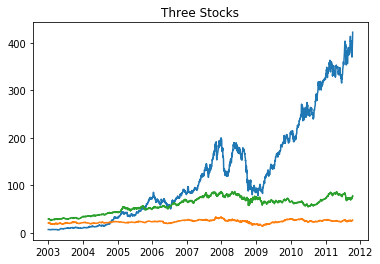

```python
plt.rcParams['font.sans-serif']=['SimHei'] #用来正常显示中文标签
plt.rcParams['axes.unicode_minus']=False #用来正常显示负号

import warnings

warnings.filterwarnings('ignore')

plt.plot(close_px)
plt.title('Three Stocks')
plt.show()
```

```python
# data.plot()
# plt.show()

# #自相关图
# from statsmodels.graphics.tsaplots import plot_acf
# plot_acf(data).show()

# #平稳性检测
# from statsmodels.tsa.stattools import adfuller as ADF
# print( ADF(data[u'销量']))
# #返回值依次为adf、pvalue、usedlag、nobs、critical values、icbest、regresults、resstore

# #差分后的结果
# D_data = data.diff().dropna()
# D_data.columns = [u'销量差分']
# D_data.plot() #时序图
# plt.show()
# plot_acf(D_data).show() #自相关图

# from statsmodels.graphics.tsaplots import plot_pacf
# plot_pacf(D_data).show() #偏自相关图
# ADF(D_data[u'销量差分'])#平稳性检测

# #白噪声检验
# from statsmodels.stats.diagnostic import acorr_ljungbox
# acorr_ljungbox(D_data, lags=1) #返回统计量和p值
```

## AAPL

### 时序图、自相关图

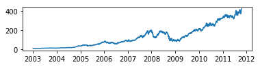

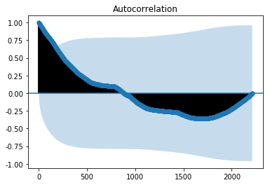

```python
AAPL = close_px[["AAPL"]]

plt.figure()
plt.subplot(3, 1, 1)
plt.plot(AAPL) #时序图
plot_acf(AAPL)#自相关图
#plot_pacf(AAPL).show()
plt.show()
```

### 平稳性与白噪声检测

```python
#单位根检测（平稳性检测）
from statsmodels.tsa.stattools import adfuller as ADF
root = ADF(AAPL['AAPL'])

if root[1] <= 0.05:
    print("该序列是平稳的，p-value %s" % root[1])
else:
    print("该序列是非平稳的，p-value %s" % root[1])

#print("单位根检测结果 \n" + str(root))
#返回值依次为adf、pvalue、usedlag、nobs、critical values、icbest、regresults、resstore

#白噪声检验
from statsmodels.stats.diagnostic import acorr_ljungbox
white = acorr_ljungbox(AAPL['AAPL'], lags=1) #返回统计量和p值

if white[1] > 0.05:
    print("该序列是一个随机序列（白噪声序列），p-value %s" % white[1])
else:
    print("该序列不是一个随机序列（白噪声序列），p-value %s" % white[1])

#print("单位根检测结果 \n" + str(white))
```

```
该序列是非平稳的，p-value 0.9977891697734111
该序列不是一个随机序列（白噪声序列），p-value [0.]
```

### 差分运算

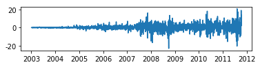

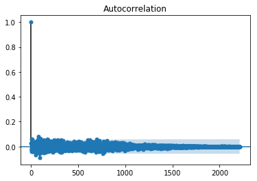

```python
#差分后的结果
D1_AAPL = AAPL.diff().dropna()
D1_AAPL.columns = [u'销量差分']

plt.subplot(3, 1, 1)
plt.plot(D1_AAPL) #时序图
plot_acf(D1_AAPL).show() #自相关图
#plot_pacf(D1_AAPL).show() #偏自相关图
plt.show()
```

### 一阶差分后的平稳性与白噪声检测

```python
print("经过1阶差分后 \n")

#单位根检测（平稳性检测）
from statsmodels.tsa.stattools import adfuller as ADF
root_D1 = ADF(D1_AAPL[u'销量差分'])

if root_D1[1] <= 0.05:
    print("该序列是平稳的，p-value %s" % root_D1[1])
else:
    print("该序列是非平稳的，p-value %s" % root_D1[1])


#print("单位根检测结果 \n" + str(root))
#返回值依次为adf、pvalue、usedlag、nobs、critical values、icbest、regresults、resstore

#白噪声检验
from statsmodels.stats.diagnostic import acorr_ljungbox
white_D1 = acorr_ljungbox(D1_AAPL[u'销量差分'], lags=1) #返回统计量和p值

if white_D1[1] > 0.05:
    print("该序列是一个随机序列（白噪声序列），p-value %s" % white_D1[1])
else:
    print("该序列不是一个随机序列（白噪声序列），p-value %s" % white_D1[1])

#print("单位根检测结果 \n" + str(white))
```

```
经过1阶差分后

该序列是平稳的，p-value 1.445218931309417e-27
该序列是一个随机序列（白噪声序列），p-value [0.2736]
```

### 定阶

```python
# 定阶
#pmax = int(len(AAPL)/100) #一般阶数不超过length/10
#qmax = int(len(AAPL)/100) #一般阶数不超过length/10
pmax = 3
qmax = 3

from statsmodels.tsa.arima_model import ARIMA
from statsmodels.tsa.arima_model import ARMA
bic_matrix = [] #bic矩阵

for p in range(pmax+1):
  tmp = []
  for q in range(qmax+1):
    try: #存在部分报错，所以用try来跳过报错。
      tmp.append(ARIMA(AAPL, (p,1,q)).fit().bic)
    except:
      tmp.append(None)
  bic_matrix.append(tmp)

bic_matrix = pd.DataFrame(bic_matrix) #从中可以找出最小值

p,q = bic_matrix.stack().idxmin() #先用stack展平，然后用idxmin找出最小值位置。
print(u'BIC最小的p值和q值为' +str((p,q)))
```

```
BIC最小的p值和q值为(0, 0)
```

```python
model = ARIMA(AAPL, (p,1,q)).fit() #建立ARIMA(0, 1, 0)模型
model.summary() #给出一份模型报告
```

ARIMA Model Results

| Dep. Variable: | D.AAPL | No. Observations: | 2213 |
| --- | --- | --- | --- |
| Model: | ARIMA(0, 1, 0) | Log Likelihood | -5731.237 |
| Method: | css | S.D. of innovations | 3.225 |
| Date: | Fri, 08 Jun 2018 | AIC | 11466.474 |
| Time: | 14:07:43 | BIC | 11477.878 |
| Sample: | 1 | HQIC | 11470.640 |

|  | coef | std err | z | P>\|z\| | [0.025 | 0.975] |
| --- | --- | --- | --- | --- | --- | --- |
| const | 0.1873 | 0.069 | 2.733 | 0.006 | 0.053 | 0.322 |

```python
model.forecast(5) #作为期5天的预测，返回预测结果、标准误差、置信区间。
```

```
(array([422.1873, 422.3747, 422.562 , 422.7494, 422.9367]),
 array([3.2248, 4.5605, 5.5855, 6.4496, 7.2108]),
 array([[415.8669, 428.5078],
        [413.4362, 431.3132],
        [411.6147, 433.5094],
        [410.1085, 435.3903],
        [408.8038, 437.0697]]))
```

```python
# bic_matrix = pd.DataFrame(bic_matrix) #从中可以找出最小值

# p,q = bic_matrix.stack().idxmin() #先用stack展平，然后用idxmin找出最小值位置。
# print(u'BIC最小的p值和q值为：%s、%s' %(p,q))
# model = ARIMA(close_px, (0,1,1)).fit() #建立ARIMA(0, 1, 1)模型
# model.summary() #给出一份模型报告
# model.forecast(5) #作为期5天的预测，返回预测结果、标准误差、置信区间。
```

## MSFT

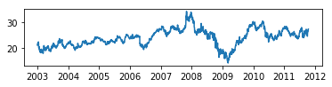

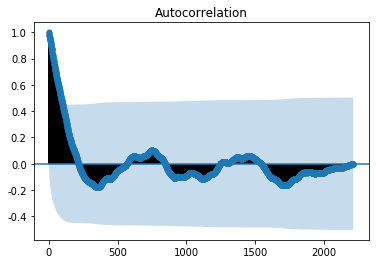

```
该序列是平稳的，单位根p-value 0.04856843065105696
该序列不是一个随机序列（白噪声序列），p-value [0.]
```

```python
MSFT = close_px[["MSFT"]]

# 时序图、自相关图与偏自相关图

plt.figure()
plt.subplot(3, 1, 1)
plt.plot(MSFT) #时序图
plot_acf(MSFT)#自相关图
#plot_pacf(MSFT).show()
plt.show()

#单位根检测（平稳性检测）
from statsmodels.tsa.stattools import adfuller as ADF
root_MSFT = ADF(MSFT['MSFT'])

if root_MSFT[1] <= 0.05:
    print("该序列是平稳的，单位根p-value %s" % root_MSFT[1])
else:
    print("该序列是非平稳的，单位根p-value %s" % root_MSFT[1])

#print("单位根检测结果 \n" + str(root))
#返回值依次为adf、pvalue、usedlag、nobs、critical values、icbest、regresults、resstore

#白噪声检验
from statsmodels.stats.diagnostic import acorr_ljungbox
white_MSFT = acorr_ljungbox(MSFT['MSFT'], lags=1) #返回统计量和p值

if white_MSFT[1] > 0.05:
    print("该序列是一个随机序列（白噪声序列），p-value %s" % white_MSFT[1])
else:
    print("该序列不是一个随机序列（白噪声序列），p-value %s" % white_MSFT[1])

#print("单位根检测结果 \n" + str(white))

#差分后的结果
D1_MSFT = MSFT.diff().dropna()
D1_MSFT.columns = [u'销量差分']
```

### 经过1阶差分后

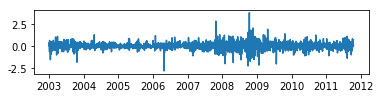

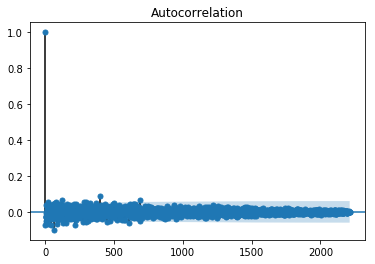

```
该序列是平稳的，单位根p-value 8.152500411316822e-16
该序列不是一个随机序列（白噪声序列），p-value [0.0007]
```

```python
plt.subplot(3, 1, 1)
plt.plot(D1_MSFT) #时序图
plot_acf(D1_MSFT).show() #自相关图
#plot_pacf(D1_MSFT).show() #偏自相关图
plt.show()



#单位根检测（平稳性检测）
from statsmodels.tsa.stattools import adfuller as ADF
D1_root_MSFT = ADF(D1_MSFT[u'销量差分'])

if D1_root_MSFT[1] <= 0.05:
    print("该序列是平稳的，单位根p-value %s" % D1_root_MSFT[1])
else:
    print("该序列是非平稳的，单位根p-value %s" % D1_root_MSFT[1])


#print("单位根检测结果 \n" + str(root))
#返回值依次为adf、pvalue、usedlag、nobs、critical values、icbest、regresults、resstore

#白噪声检验
from statsmodels.stats.diagnostic import acorr_ljungbox
D1_white_MSFT = acorr_ljungbox(D1_MSFT[u'销量差分'], lags=1) #返回统计量和p值

if D1_white_MSFT[1] > 0.05:
    print("该序列是一个随机序列（白噪声序列），p-value %s" % D1_white_MSFT[1])
else:
    print("该序列不是一个随机序列（白噪声序列），p-value %s" % D1_white_MSFT[1])
```

```python
#再做一次差分
D2_MSFT = D1_MSFT.diff().dropna()
D2_MSFT.columns = [u'销量差分']
```

### 经过2阶差分后

```python
#白噪声检验
from statsmodels.stats.diagnostic import acorr_ljungbox
D2_white_MSFT = acorr_ljungbox(D2_MSFT[u'销量差分'], lags=1) #返回统计量和p值

if D2_white_MSFT[1] > 0.05:
    print("该序列是一个随机序列（白噪声序列），p-value %s" % D2_white_MSFT[1])
else:
    print("该序列不是一个随机序列（白噪声序列），p-value %s" % D2_white_MSFT[1])
```

```
该序列不是一个随机序列（白噪声序列），p-value [0.]
```

```python
#print("单位根检测结果 \n" + str(white))

# 定阶
#pmax = int(len(MSFT)/100) #一般阶数不超过length/10
#qmax = int(len(MSFT)/100) #一般阶数不超过length/10
pmax = 3
qmax = 10
```

```python
from statsmodels.tsa.arima_model import ARIMA
from statsmodels.tsa.arima_model import ARMA
bic_matrix = [] #bic矩阵

for p in range(pmax+1):
  tmp = []
  for q in range(qmax+1):
    try: #存在部分报错，所以用try来跳过报错。
      tmp.append(ARIMA(AAPL, (p,1,q)).fit().bic)
    except:
      tmp.append(None)
  bic_matrix.append(tmp)

bic_matrix = pd.DataFrame(bic_matrix) #从中可以找出最小值

p,q = bic_matrix.stack().idxmin() #先用stack展平，然后用idxmin找出最小值位置。
print(u'BIC最小的p值和q值为' +str((p,q)))

model = ARIMA(AAPL, (p,1,q)).fit() #建立ARIMA(0, 1, 0)模型
model.summary() #给出一份模型报告
```

```
BIC最小的p值和q值为(0, 0)
```

ARIMA Model Results

[output not shown]

|  | coef | std err | z | P>\|z\| | [0.025 | 0.975] |
| --- | --- | --- | --- | --- | --- | --- |
| const | 0.1873 | 0.069 | 2.733 | 0.006 | 0.053 | 0.322 |

## XOM

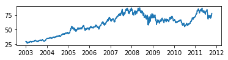

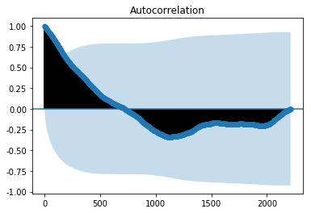

```
该序列是非平稳的，单位根p-value 0.45680498648995127
该序列不是一个随机序列（白噪声序列），p-value [0.]
```

```python
XOM = close_px[["XOM"]]

# 时序图、自相关图与偏自相关图

plt.figure()
plt.subplot(3, 1, 1)
plt.plot(XOM) #时序图
plot_acf(XOM)#自相关图
#plot_pacf(XOM).show()
plt.show()

#单位根检测（平稳性检测）
from statsmodels.tsa.stattools import adfuller as ADF
root_XOM = ADF(XOM['XOM'])

if root_XOM[1] <= 0.05:
    print("该序列是平稳的，单位根p-value %s" % root_XOM[1])
else:
    print("该序列是非平稳的，单位根p-value %s" % root_XOM[1])

#print("单位根检测结果 \n" + str(root))
#返回值依次为adf、pvalue、usedlag、nobs、critical values、icbest、regresults、resstore

#白噪声检验
from statsmodels.stats.diagnostic import acorr_ljungbox
white_XOM = acorr_ljungbox(XOM['XOM'], lags=1) #返回统计量和p值

if white_XOM[1] > 0.05:
    print("该序列是一个随机序列（白噪声序列），p-value %s" % white_XOM[1])
else:
    print("该序列不是一个随机序列（白噪声序列），p-value %s" % white_XOM[1])

#print("单位根检测结果 \n" + str(white))

#差分后的结果
D1_XOM = XOM.diff().dropna()
D1_XOM.columns = [u'销量差分']
```

### 经过1阶差分后

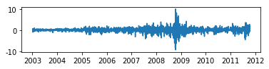

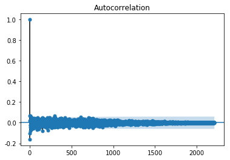

```
该序列是平稳的，单位根p-value 4.749460656483745e-24
该序列不是一个随机序列（白噪声序列），p-value [0.]
```

```python
plt.subplot(3, 1, 1)
plt.plot(D1_XOM) #时序图
plot_acf(D1_XOM).show() #自相关图
#plot_pacf(D1_XOM).show() #偏自相关图
plt.show()



#单位根检测（平稳性检测）
from statsmodels.tsa.stattools import adfuller as ADF
D1_root_XOM = ADF(D1_XOM[u'销量差分'])

if D1_root_XOM[1] <= 0.05:
    print("该序列是平稳的，单位根p-value %s" % D1_root_XOM[1])
else:
    print("该序列是非平稳的，单位根p-value %s" % D1_root_XOM[1])


#print("单位根检测结果 \n" + str(root))
#返回值依次为adf、pvalue、usedlag、nobs、critical values、icbest、regresults、resstore

#白噪声检验
from statsmodels.stats.diagnostic import acorr_ljungbox
D1_white_XOM = acorr_ljungbox(D1_XOM[u'销量差分'], lags=1) #返回统计量和p值

if D1_white_MSFT[1] > 0.05:
    print("该序列是一个随机序列（白噪声序列），p-value %s" % D1_white_XOM[1])
else:
    print("该序列不是一个随机序列（白噪声序列），p-value %s" % D1_white_XOM[1])
```

```python
#print("单位根检测结果 \n" + str(white))

# 定阶
#pmax = int(len(XOM)/100) #一般阶数不超过length/10
#qmax = int(len(XOM)/100) #一般阶数不超过length/10
pmax = 3
qmax = 10
```

```python
from statsmodels.tsa.arima_model import ARIMA
from statsmodels.tsa.arima_model import ARMA
bic_matrix = [] #bic矩阵

for p in range(pmax+1):
  tmp = []
  for q in range(qmax+1):
    try: #存在部分报错，所以用try来跳过报错。
      tmp.append(ARIMA(AAPL, (p,1,q)).fit().bic)
    except:
      tmp.append(None)
  bic_matrix.append(tmp)

bic_matrix = pd.DataFrame(bic_matrix) #从中可以找出最小值

p,q = bic_matrix.stack().idxmin() #先用stack展平，然后用idxmin找出最小值位置。
print(u'BIC最小的p值和q值为' +str((p,q)))

model = ARIMA(AAPL, (p,1,q)).fit() #建立ARIMA(0, 1, 0)模型
model.summary() #给出一份模型报告
```

```
BIC最小的p值和q值为(0, 0)
```

ARIMA Model Results

[output not shown]

|  | coef | std err | z | P>\|z\| | [0.025 | 0.975] |
| --- | --- | --- | --- | --- | --- | --- |
| const | 0.1873 | 0.069 | 2.733 | 0.006 | 0.053 | 0.322 |